# Sample Document

# Introduction

The Tufte- [^1] document classes define a style similar to the style Edward Tufte uses in his books and handouts. Tufte’s style is known for its extensive use of sidenotes, tight integration of graphics with text, and well-set typography.

# Headings

This style provides a- and b-heads (that is, `#` and `##`), demonstrated above. An error is emitted if you try to use `###` and smaller headings.

# Figures

## Margin Figures

Images and graphics play an integral role in Tufte’s work. To place figures or tables in the margin you can use the `fig.margin` knitr chunk option. For example:

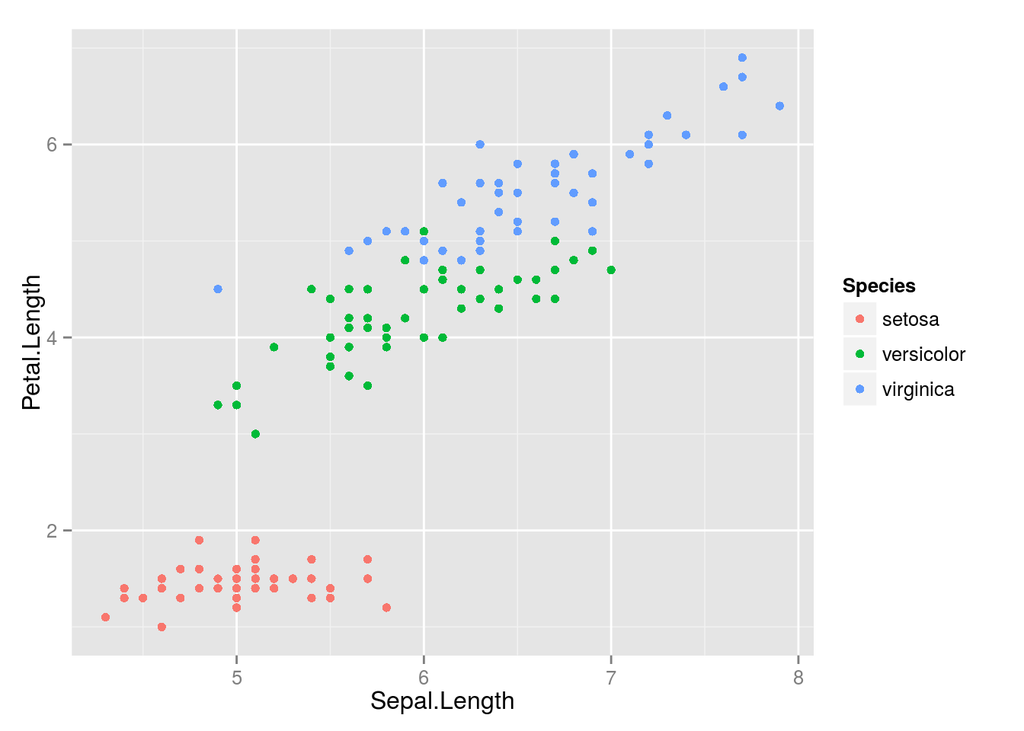

Note the use of the `fig.cap` chunk option to provide a figure caption. You can adjust the proportions of figures using the `fig.width` and `fig.height` chunk options. These are specified in inches, and will be automatically scaled down to fit within the handout margin.